# Preliminary Python Setup

```python
# Import packages that will be used in this notebook
import matplotlib.pyplot as plt
import pandas as pd
import numpy as np
import seaborn as sns
```

```python
# Read the data into a panda dataframe
data = pd.read_csv("vehicles.csv")
```

# Data Exploration

First examine the dataset to determine which variables may be of most use. Typically, variables that are numerical and not "object" or "string" are the ones that will be the easiest to model. However, as seen later on, they can be encoded/translated into numbers.

Initially viewing the size of each variable can be helpful, for example, "county" has only null entries, therefore rending the variable useless. It can also indicate how populated some of the variables regarding those containing NaN.

```python
# Display information about each variable
print(data.info())
```

```
<class 'pandas.core.frame.DataFrame'>
RangeIndex: 426880 entries, 0 to 426879
Data columns (total 26 columns):
 #   Column        Non-Null Count   Dtype
---  ------        --------------   -----
 0   id            426880 non-null  int64
 1   url           426880 non-null  object
 2   region        426880 non-null  object
 3   region_url    426880 non-null  object
 4   price         426880 non-null  int64
 5   year          425675 non-null  float64
 6   manufacturer  409234 non-null  object
 7   model         421603 non-null  object
 8   condition     252776 non-null  object
 9   cylinders     249202 non-null  object
```

[output cut: 19 more lines]

Variables that are not numerical will need to be converted into numeric values if they are to be used. This can be done in a variety of ways, and is done later on in this notebook manually - though this can be done using a method from SKlearn.

To approach the problem of needing only numerical values, a lot of the variables are missing a fair amount of values and encoding all of the categorical variables into numerical values may be a waste of time/computing power. Therefore, the variables to encode are decided upon before encoding them. The first step in this approach is to remove any variable with more than 40% of its value that are `NaN` (or any synonymous value).

```python
# Create a list that contains a boolean that defines whether the variables has more than 40% of its variables as NaN (or a substitute thereof).
cond = (data.isna().sum() / data.shape[0] < 0.4).values
# Apply previous list to the dataframe, removing any variables that have the value `False`
data = data.loc[:, cond]
```

The next choice to make is more a matter of common sense. There are some unique variables like: `image_url`, `description`, `region_url`, `url`, `VIN` and `id`. Since these are unique to the individual posting, these can also be removed as they do not give any information and without looking into further do not hold any predictive power (from face value at least). Furthermore, some variables are subjective, for example `title_status` which describes the current status of the car. This may contain some information regarding the price, however it is removed as there are more important variables to investigate. `posting_date` is of a similar informative level and thus is removed.

```python
# Remove aforementioned columns (specifying inplace to remove them from the original data)
data.drop(columns=["image_url", "description", "region_url",
                   "url", "id", "title_status", "VIN", "posting_date"], inplace=True)
```

Another point of concern is the amount of unique values in non-numerical values can be challenging to deal with - especially if they all have to be encoded. Any non-numerical value with less than 10 unique values can be dealt with fairly easily and thus, any variable with more than 10 unique values is dropped.

```python
# Print then number of unique values for each variable
print(
    "Unique values:",
    "\nregion:", len(data.region.unique()),
    "\nmanufacturer:", len(data.manufacturer.unique()),
    "\nmodel:", len(data.model.unique()),
    "\nfuel:", len(data.fuel.unique()),
    "\ntransmission:", len(data.transmission.unique()),
    "\nstate:", len(data.state.unique()),
    "\npaint colour:", len(data.paint_color.unique()),
    "\ntype:", len(data.type.unique()),
    "\ndrive:", len(data.drive.unique())
)
```

```
Unique values:
region: 404
manufacturer: 43
model: 29668
fuel: 6
transmission: 4
state: 51
paint colour: 13
type: 14
drive: 4
```

Here the variables identified with more than 10 unique values are: `region`, `manufacturer`, `model`, `state`, `paint colour`, `type`. These are then removed.

```python
# Remove all variables with more than 10 unique variables (again specifying inplace to modify the original data)
data.drop(columns=["region", "manufacturer", "model",
          "state", "paint_color", "type"], inplace=True)
```

Now that all of the variables that I have deemed unnecessary have been removed, the non-numerical variables must be converted into numerical values. For this, I will use an arbitrary labelling system, just assigning the number 0 to `other` and an increasing number for each different category. Note that the `NaN` (or derivatives thereof) are left in so that they can be converted to the median values later on.

```python
# Create a nested dictionary containing the respective values and what to replace them with for each variable
replace_dict = {
    "fuel": {
        "other": 0,
        "electric": 1,
        "gas": 2,
        "hybrid": 3,
        "diesel": 4
    },
    "transmission": {
        "other": 0,
        "manual": 1,
        "automatic": 2

    },
    "drive": {
        "4wd": 0,
        "rwd": 1,
        "fwd": 2
    }
}
# Replace above values with their numerical values
data.replace(replace_dict, inplace=True)
```

As mentioned, there are still some values that are `NaN` that need to be dealt with. This can be done using a method from SKlearn to fill in the values with whatever necessary. In this case, the median value from each variable is used to replace these values. The reason the median is used, is due to the fact that the median value chosen is a known value from the data set, whereas something like the mean may be a decimal value that does not fall into one of the encoded values.

```python
# Initialise the impute package
from sklearn.impute import SimpleImputer
# Define the imputer class object
imputer = SimpleImputer(strategy="median")
# Pass our data to the imputer
imputer.fit(data)
# Replace all values that take on NaN to the median of each variable
imputer_output = imputer.transform(data)
# Replace the original data with the imputed data
data = pd.DataFrame(
    imputer_output, columns=data.columns, index=data.index)
```

The next thing to explore is the correlation between variables, more so the correlation between the price and each explanatory variable. This will give an indication of how likely each of the variables are to impact the price after the model is fit. While the numerical value for the correlation are handy, I personally find them very difficult to compare, therefore they are plotted on a heat map annotated with numbers.

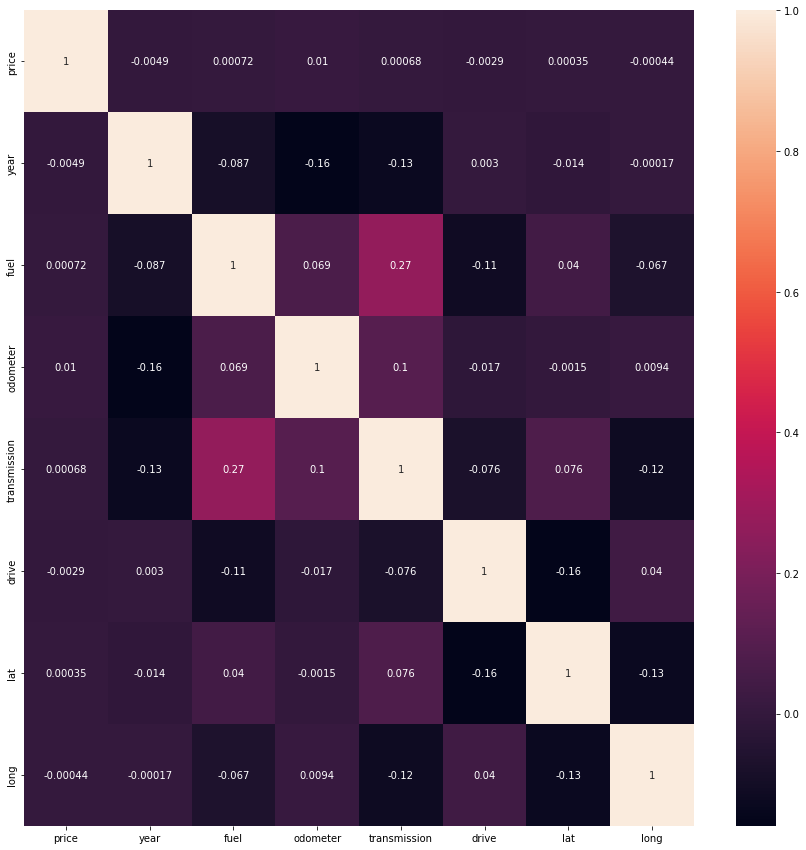

```python
# Initialise the figure object
fig, ax = plt.subplots(figsize=(15, 15))
# Call the heatmap function from seaborne to display the correlation matrix
# I use the seaborne feature over imshow (from matplotlib) and the correlation matrix from pandas as it shows the numerical information and also provides a decent visualisation too
ax = sns.heatmap(data.corr(), annot=True)
# Show the seaborne object
plt.show()
```

Since the correlation between the price and other variables are the only thing that matters, the relationship between them can be observed. As an aside, as less variables are compared, the correlation increases between the variables that remain - this is important when observing the correlation after even more variables are removed.

```python
# Display the absolute values for the correlation between all variables and price (sorted lowest to highest)
print(abs(data.corr()["price"]).sort_values())
```

```
lat             0.000348
long            0.000436
transmission    0.000684
fuel            0.000722
drive           0.002892
year            0.004926
odometer        0.010035
price           1.000000
Name: price, dtype: float64
```

There is no particularly strong relationship between any of the variables and the price. In this case, the top 5 variables will be selected to explore further, these are: `odometer`, `year`, `drive`, `transmission` and `fuel`. In other words, the longitude and latitude values are removed from the ongoing data exploration.

```python
# Select the top 5 correlated variables and remove all others from the dataframe
data = data.loc[:, ["price", "transmission",
                    "fuel", "drive", "year", "odometer"]]
```

The relationship of these variables to the price can be individually explored by using a simple scatter plot. This will also highlight any extra pruning/manipulation of any of the variables that needs to be done.

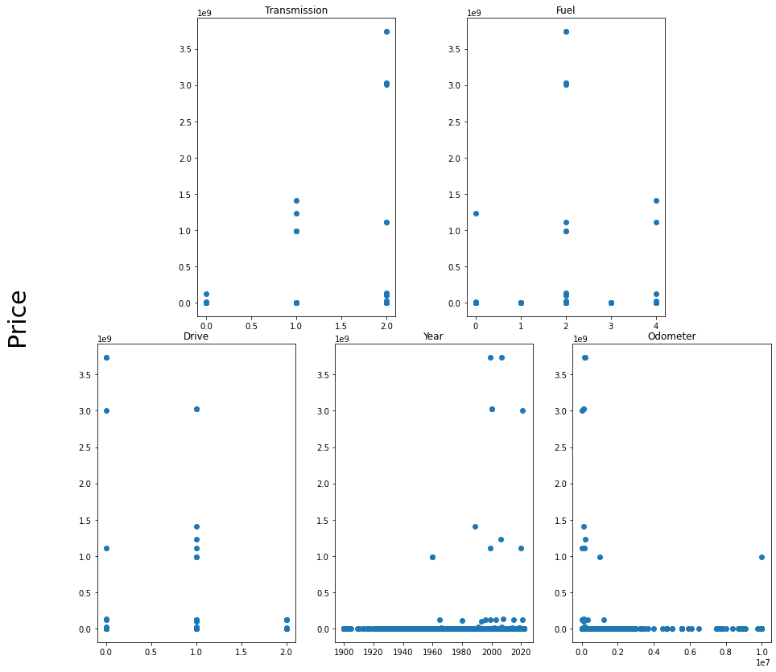

```python
# Initialise the plot object
fig, axs = plt.subplots(2, 3, figsize=(15, 15))
# Set one of the axis to be invisible (since we are only comparing 5 variables to 1 there will be one plot missing)
axs[0][0].set_visible(False)
# Move two plots to be more central
axs[0][1].set_position([0.24, 0.5, 0.228, 0.343])
axs[0][2].set_position([0.55, 0.5, 0.228, 0.343])


# Loop through both the: variables from the data frame, and the axis array (defining each of the individual plots)
for to_plot, ax in zip(data, axs.ravel()):
    # Plot each variable against price
    ax.scatter(x=data[to_plot], y=(data["price"]))
    # Set the title of each plot to the variable being compared
    ax.title.set_text(to_plot.capitalize())

# Set the common y-axis label to "price"
fig.supylabel("Price", fontsize=30)
# Show the plot object
plt.show()
```

The first thing that this plot reveals is that there is evidently some outliers in the data. Further analysis of the price values indicates that some entries are randomly high, or some entries are listed as "123456" or "111111". This is extremely difficult to remove every entry similar to this, a potential method may be to scan the description of the sale and it may mention "price negotiable" or similar - indicating that the listing price is arbitrary. In an attempt to counter this however, it seems that there are only some outliers which is skewing the data and thus the prices are limited to a maximum of $120,000 to avoid any obnoxiously large values.

Also the the scale for `odometer` will be converted in to a $log_{10}$ relationship in an effort to accurately model the relationship between it and the price. Note that this is only for visualisation purposes as the machine learning methods do not exclusively assume a linear relationship between predictor and estimator.

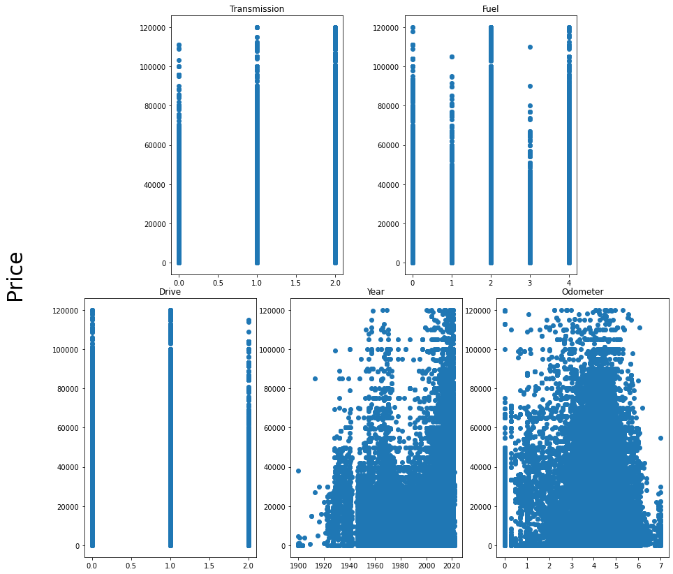

```python
# Select all data where the price is below 120000
data = data[(data["price"] < 120000)]



# Same as before, initialise the figure object and modify the plot locations
fig, axs = plt.subplots(2, 3, figsize=(15, 15))
axs[0][0].set_visible(False)
axs[0][1].set_position([0.24, 0.5, 0.228, 0.343])
axs[0][2].set_position([0.55, 0.5, 0.228, 0.343])

# Same as before, loop through the axis and the variables to plot
for to_plot, ax in zip(data, axs.ravel()):
    # However, change the x-axis for the the odometer variable to be on a log10 scale
    if to_plot == "odometer":
        ax.scatter(x=np.log10(data[to_plot]), y=(data["price"]))
    else:
        ax.scatter(x=(data[to_plot]), y=(data["price"]))
    ax.title.set_text(to_plot.capitalize())


fig.supylabel("Price", fontsize=30)
plt.show()
```

From the above plots, there is a clear relationship between `price` and `odometer` and `year` - they indicate a large variation and some kind of trend in the data. Since `transmission`, `fuel` and `drive` are categorical, it is more difficult to establish a clear relationship between the variables and `price`.

```python
# Again, display the absolute correlation value
abs(data.corr()["price"]).sort_values()
```

```
fuel            0.040929
odometer        0.146008
drive           0.237481
transmission    0.257023
year            0.284382
price           1.000000
Name: price, dtype: float64
```

# Model Fitting

There are several directions to take the model fitting. In this report, I will fit the variables to two separate models; a decision tree regressor model and a random forest model. This will help to establish a "better" model and it will also help to provide some sort of comparison/benchmark to help decide how good the model is.

I will assess the quality of fit of each model and compare them side by side and then perform cross validation on the data (more on this later in the fitting).

The first thing to do is create a training and testing set of data into an 80/20 split respectively. This is so that fit of the model can be assessed on data that it has not seen before.

```python
# Import SKlearns method to split the data randomly into a training set and a test set
from sklearn.model_selection import train_test_split
# Using list comprehension, split the values 80/20 into a training and testing set, where X is the explanatory variables and Y is the predicted variable. The list comprehension ensures only the values are returned as a numpy array and there is no obsolete text attached.
X_train, X_test, Y_train, Y_test = [x.values for x in train_test_split(
    data.filter(["transmission", "drive", "year", "odometer"]),
    data.filter(["price"]),
    random_state=2607,
    test_size=0.2
)]
```

The next step is to initialise both models from the SKlearn package. Since the data is on the most part numerical and the categorical variables have been translated to numerical values, the regression models are used.

```python
# Import the methods used for the model from SKlearn
from sklearn.tree import DecisionTreeRegressor
from sklearn.ensemble import RandomForestRegressor

# Initialise the class objects that will be used and fitted to later on
DTR = DecisionTreeRegressor(random_state=2607)
# Here use `n_jobs = -1` for parallel computing (-1 means use all cores) to speed up the process
RFR = RandomForestRegressor(n_estimators=100, n_jobs=-1, random_state=2607)
```

Fit the training data to each of the models and make predictions based on the testing data.

```python
# Fit both of the models to the training data (using ravel to flatten the array)
DTR.fit(X_train, Y_train.ravel())
RFR.fit(X_train, Y_train.ravel())

# Make predictions from the model using the testing data
DTR_predictions = DTR.predict(X_test)
RFR_predictions = RFR.predict(X_test)
```

Calculate and display the relevant metrics. This is where the testing dataset comes in useful, especially for the training score, which determines how many of the data points are predicted by the already determined model.

```python
# Import the metrics module from SKlearn to display detailed information on each of the modules
from sklearn import metrics

# Print out relevant information
print(
    "Decision tree: \nTraining score:", round(
        DTR.score(X_test, Y_test), ndigits=2),
    "\nMean Absolute Error:", round(
        metrics.mean_absolute_error(Y_test, DTR_predictions)),
    "\nMean Squared Error:", round(metrics.mean_squared_error(
        Y_test, DTR_predictions)),
    "\nMean of Price:", round(float(np.mean(Y_test))),
    "\nError %:", round(metrics.mean_absolute_error(
        Y_test, DTR_predictions) / float(np.mean(Y_test)), ndigits=2)
)

print(
    "\nRandom Forest: \nTraining score:", round(
        RFR.score(X_test, Y_test), ndigits=2),
    "\nMean Absolute Error:", round(
        metrics.mean_absolute_error(Y_test, RFR_predictions)),
    "\nMean Squared Error:", round(metrics.mean_squared_error(
        Y_test, RFR_predictions)),
    "\nMean of Price:", round(float(np.mean(Y_test))),
    "\nError %:", round(metrics.mean_absolute_error(
        Y_test, RFR_predictions) / float(np.mean(Y_test)), ndigits=2)
)
```

```
Decision tree:
Training score: 0.56
Mean Absolute Error: 4548
Mean Squared Error: 99913174
Mean of Price: 17349
Error %: 0.26

Random Forest:
Training score: 0.64
Mean Absolute Error: 4551
Mean Squared Error: 79989923
Mean of Price: 17349
Error %: 0.26
```

The metrics give a good insight to the model and it is helpful to compare this to another model. Having this comparison can also aid in choosing the correct model for the dataset.

Firstly, comparing the two models, the random forest model is better than the decision tree model since it has a higher training score. This training score is representative of how well the model predictions match the test data that was reserved earlier. Ultimately, the higher the training score, the better the model (or has a higher predictive power).

Secondly, the mean absolute error is very similar, with just a difference of 3.

Thirdly, the mean squared error is much less using the random forest model - a difference of around 20 million.

As a final note, there is a very similar error as a function of the price. Both models could be better but in this case, the random forest model is ever so slightly better due to the higher training score.

To take the analysis of each model even further, the cross validation score (CVS) can be calculated. The CVS is calculated by doing a similar thing as done above. Cross validation splits the data into different sets of data (in this case 10 different sets) and trains the data and compares it to the testing data. Here it is greatly simplified by SKlearn's algorithm and instead of performing the split manually (with the function `train_test_split`) it is done automatically and semi-randomly.

The main reason for CVS here is to identify that the models are formed independently to the splitting of the data.

```python
# Import the cross validation method
from sklearn.model_selection import cross_val_score

# Choose the number of folds (the number of times the data is split)
K = 10

# For cross-validation a new model needs to be initialised
new_RF = RandomForestRegressor(n_estimators=100, random_state=2607, n_jobs=-1)
new_DT = DecisionTreeRegressor(random_state=2607)


# Perform cross-validation, with all the data fed to it
DT_scores = cross_val_score(new_DT,
                            data.filter(
                                ["transmission", "drive", "year", "odometer"]),
                            data.filter(["price"]), cv=K,
                            n_jobs=-1, scoring="neg_mean_squared_error")


RF_scores = cross_val_score(new_RF,
                            data.filter(
                                ["transmission", "drive", "year", "odometer"]),
                            data.filter(["price"]), cv=K,
                            n_jobs=-1, scoring="neg_mean_squared_error")

# Since the scoring method was negative mean squared error, the actual error is the square of the positive value
DT_scores = np.sqrt(-DT_scores)
RF_scores = np.sqrt(-RF_scores)
```

Now calculate the relevant metrics for the cross-validation process. Here, the lower the score, the better the model.

```python
# Output relevant metrics
print("Decision Tree:",
      "\nScores:", np.round(DT_scores),
      "\nMean Score:", np.round(DT_scores.mean()),
      "\nStandard deviation:", np.round(DT_scores.std()))

print("\nRandom Forest:",
      "\nScores:", np.round(RF_scores),
      "\nMean Score:", np.round(RF_scores.mean()),
      "\nStandard deviation:", np.round(RF_scores.std()))
```

```
Decision Tree:
Scores: [12638. 12555. 12659. 12055. 10253. 11702. 11194. 13079. 12301. 13460.]
Mean Score: 12190.0
Standard deviation: 893.0

Random Forest:
Scores: [11318. 11090. 11266. 10559.  9035. 10361.  9856. 11923. 10870. 12052.]
Mean Score: 10833.0
Standard deviation: 874.0
```

In this case, the majority of the scores from the random forest regression are lower than the majority of scores from the decision tree. This reinforces that the random forest model is better than the decision tree model.